# MilestoneReport

Artem Vovk

7/29/2017

## Instructions

The goal of this project is just to display that you’ve gotten used to working with the data and that you are on track to create your prediction algorithm. Please submit a report on R Pubs (http://rpubs.com/) that explains your exploratory analysis and your goals for the eventual app and algorithm. This document should be concise and explain only the major features of the data you have identified and briefly summarize your plans for creating the prediction algorithm and Shiny app in a way that would be understandable to a non-data scientist manager. You should make use of tables and plots to illustrate important summaries of the data set. The motivation for this project is to: 1. Demonstrate that you’ve downloaded the data and have successfully loaded it in. 2. Create a basic report of summary statistics about the data sets. 3. Report any interesting findings that you amassed so far. 4. Get feedback on your plans for creating a prediction algorithm and Shiny app.

## Get the Data

- We have 3 data sources:
- Twitter, Blogs, News
- Each data source comes in 4 different languages:
- German, English, Finnish, Russian

The size on disk is: 1.4 GB - German - ~250 MB - English - ~500 MB = Finnish - ~230 MB - Russian - ~340 MB

Let’s look at line counts just for fun:

**NB** I made my own little function to load the files locally (because uploading all this to RPubs is a bad idea). For original data [see this](https://d396qusza40orc.cloudfront.net/dsscapstone/dataset/Coursera-SwiftKey.zip).

```r
sources <- c("twitter", "blogs", "news")
languages <- c("de_DE", "en_US", "fi_FI", "ru_RU")
for(lang in languages){
    for(source in sources){
        con <- load_file_con(source, lang)
        sample <- suppressWarnings(readLines(con, encoding = "UTF-8"))
        print(paste0(c(source, " in ", lang, " has ", length(sample), " lines."), collapse = ""))
        close(con)
    }
}
```

```
## [1] "twitter in de_DE has 947774 lines."
## [1] "blogs in de_DE has 371440 lines."
## [1] "news in de_DE has 244743 lines."
## [1] "twitter in en_US has 2360148 lines."
## [1] "blogs in en_US has 899288 lines."
## [1] "news in en_US has 1010242 lines."
## [1] "twitter in fi_FI has 285214 lines."
## [1] "blogs in fi_FI has 439785 lines."
## [1] "news in fi_FI has 485758 lines."
## [1] "twitter in ru_RU has 881414 lines."
## [1] "blogs in ru_RU has 337100 lines."
## [1] "news in ru_RU has 196360 lines."
```

### Some more Summary Statistics

```r
sources <- c("twitter", "blogs", "news")
languages <- c("de_DE", "en_US", "fi_FI", "ru_RU")
subsamples <- data.frame(Source = character(12), Sample = character(12), stringsAsFactors = FALSE)
names <- list(12)
samples <- list(12)
counter <- 1
for(lang in languages){
    for(source in sources){
        con <- load_file_con(source, lang)
        data <- suppressWarnings(readLines(con, n=1000, encoding = "UTF-8"))
        names[counter] <- paste0(c(source, lang), collapse = "_")
        samples[[counter]] <- data
        close(con)
        counter <- counter+1
    }
}
subsamples$Source <- names
subsamples$Sample <- samples
```

In order to get things like word counts and etc, I used `tm` package to make `Corpus` out of each of the collected data samples. Using that package it is pretty easy to collect word frequencies using the two functions below:

```r
getFreqWords <- function(docs, wordL = c(4,20), top = 10){
    docs <- Corpus(VectorSource(unlist(docs)))
    if((class(docs) != "TermDocumentMatrix")[1] & (class(docs) != "DocumentTermMatrix")[1]){
        docs <- DocumentTermMatrix(docs, control=list(wordLengths=wordL,
                                                      bounds = list(global = c(3, (length(docs)/1.5)) )))
    }
    freq <- colSums(as.matrix(docs))
    ord <- order(freq, decreasing = TRUE)
    freq <- freq[head(ord, top)]
    return(freq)
}

freqDF <- function(docs, wordSize = c(4,20), head = 15){
    wordSize <- c(as.numeric(wordSize[1]),as.numeric(wordSize[2]))
    freq <- getFreqWords(docs, wordL = wordSize, top = as.numeric(head))
    if(length(freq) == 0){
        return(NULL)
    }
    freq <- data.frame(word = names(freq), frequency = freq)
    return(freq)
}

freqDF(subsamples$Sample[[12]])
```

```
##     word frequency
## на    на       895
## не    не       665
## что  что       514
## по    по       445
## из    из       247
## это  это       235
## как  как       233
## но    но       219
## за    за       211
## то    то       178
## от    от       177
## для  для       175
## он    он       161
## все  все       135
## его  его       133
```

```r
freqDF(subsamples$Sample[[6]])
```

```
##        word frequency
## that   that       351
## said   said       259
## with   with       252
## from   from       139
## have   have       139
## they   they       123
## will   will       105
## more   more       102
## this   this        99
## year   year        96
## their their        81
## would would        70
## when   when        65
## first first        64
## what   what        63
```

So it seems like determining word length is non-trivial for non-Latin languages. Additionally, it is clear that most frequent words would probably what’s called “stop words.” These tasks are to be left for data pre-processing. however.

## Plot the data

For now, let’s just avoid the last part by upping the minimum word-length and make a histogram:

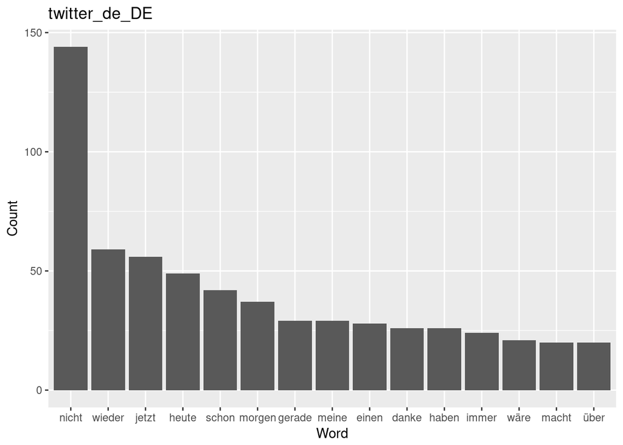

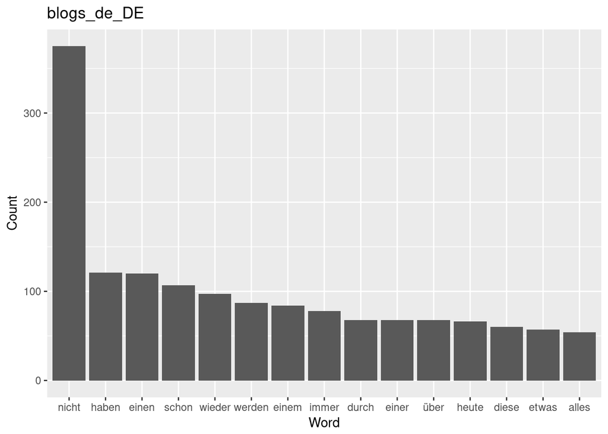

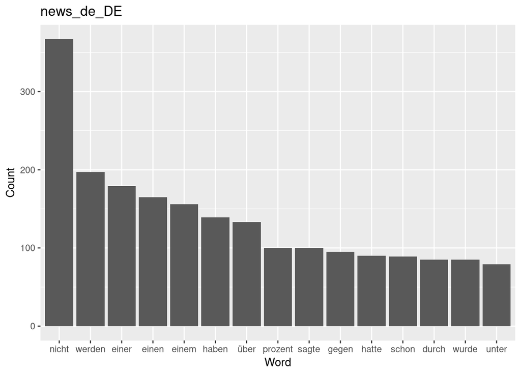

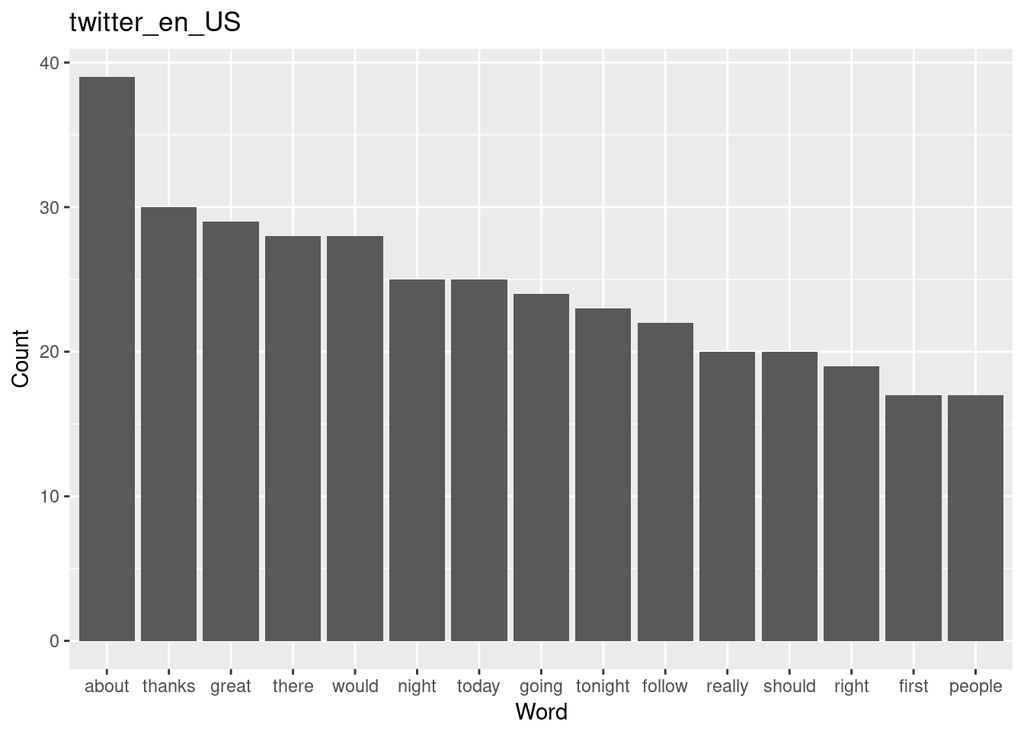

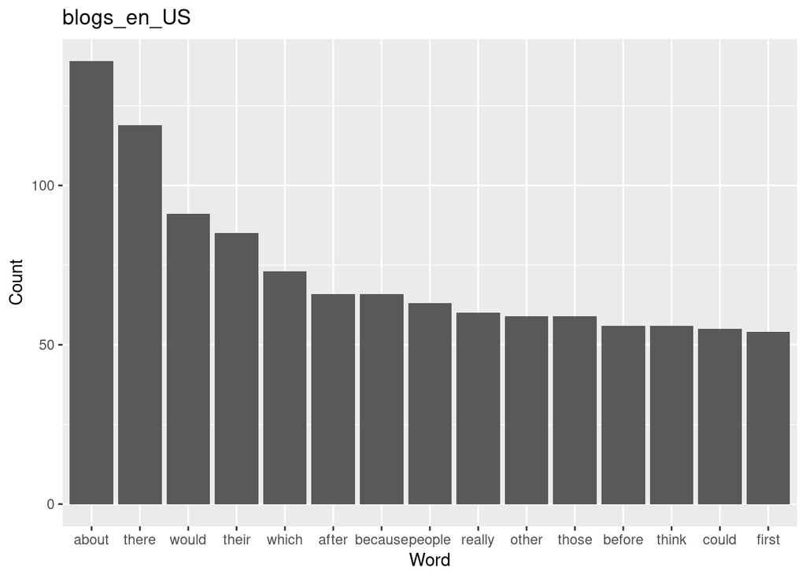

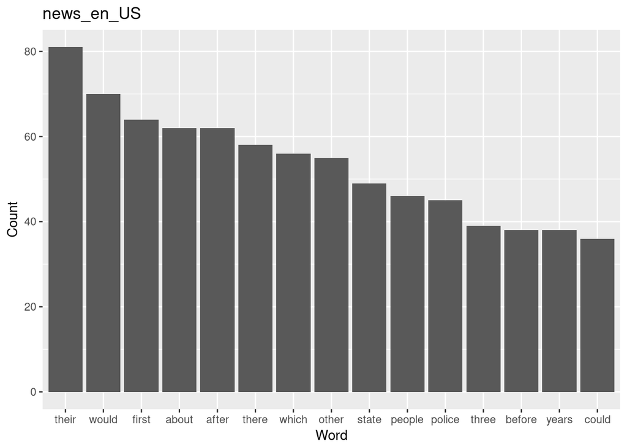

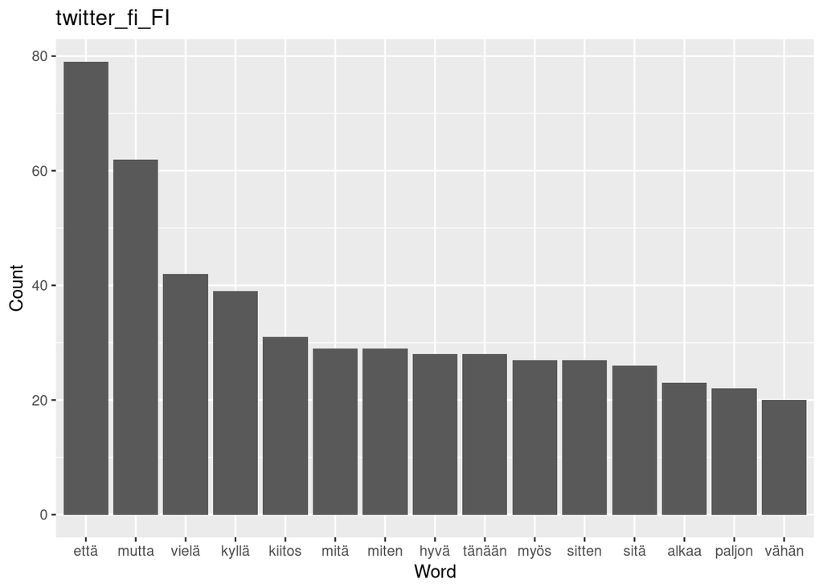

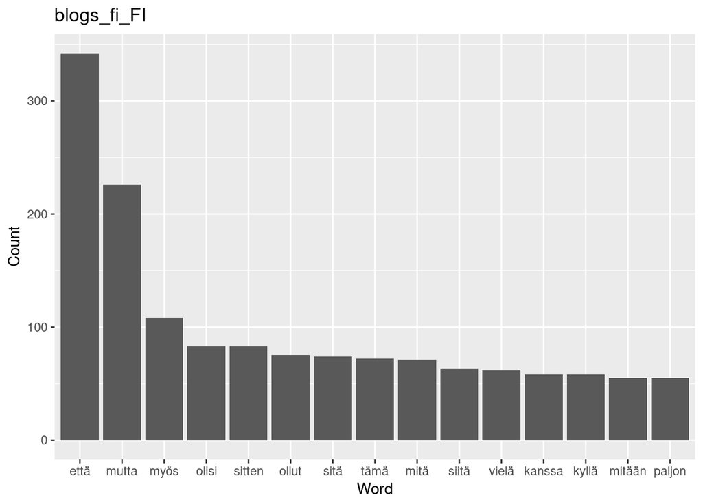

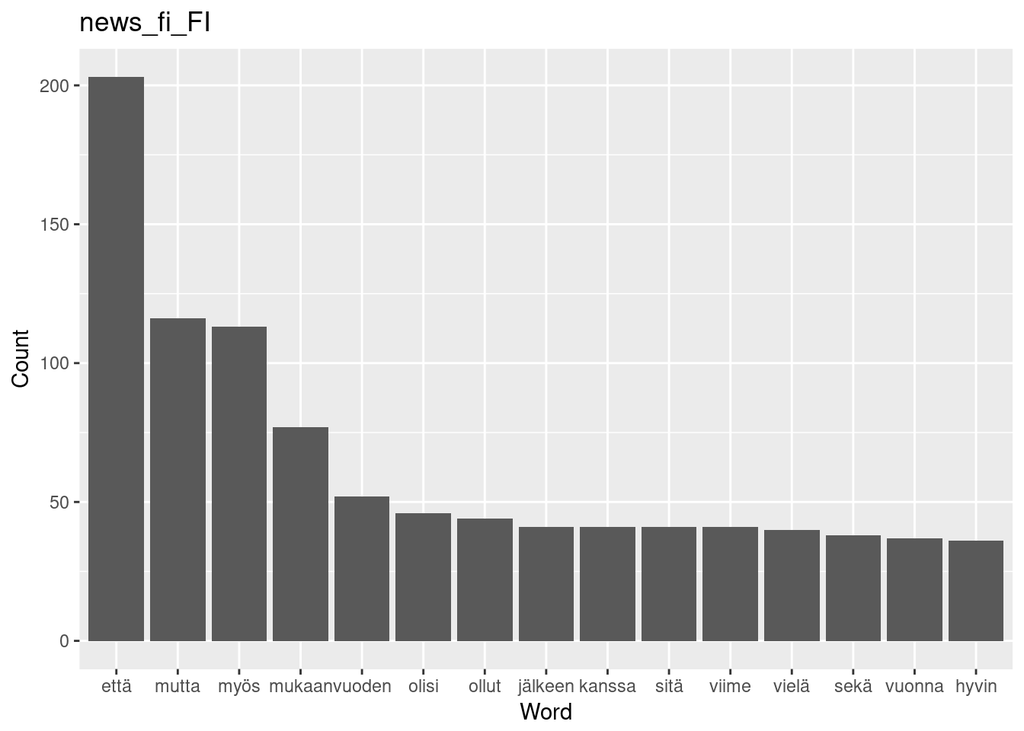

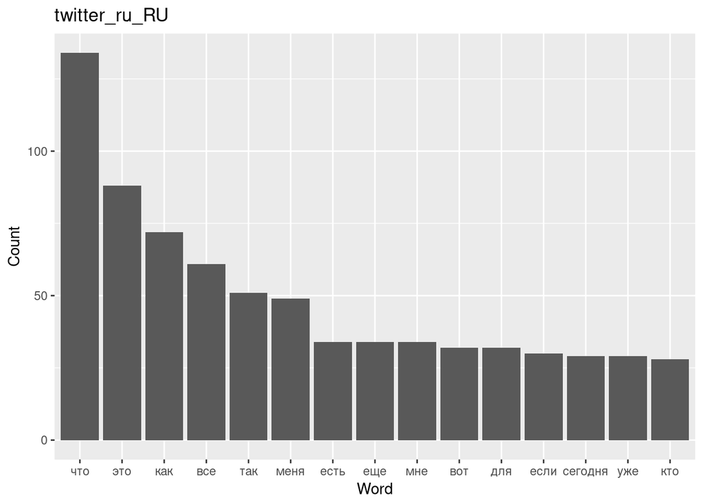

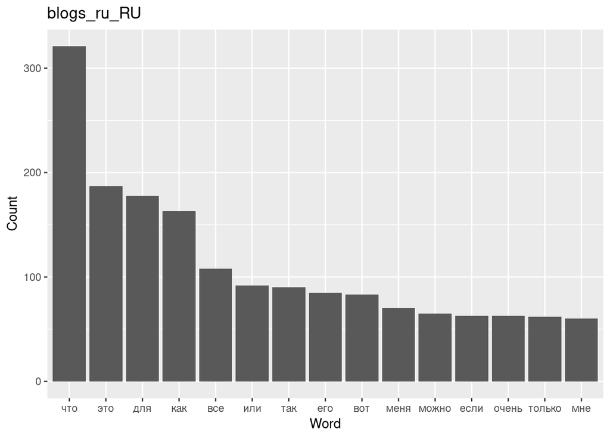

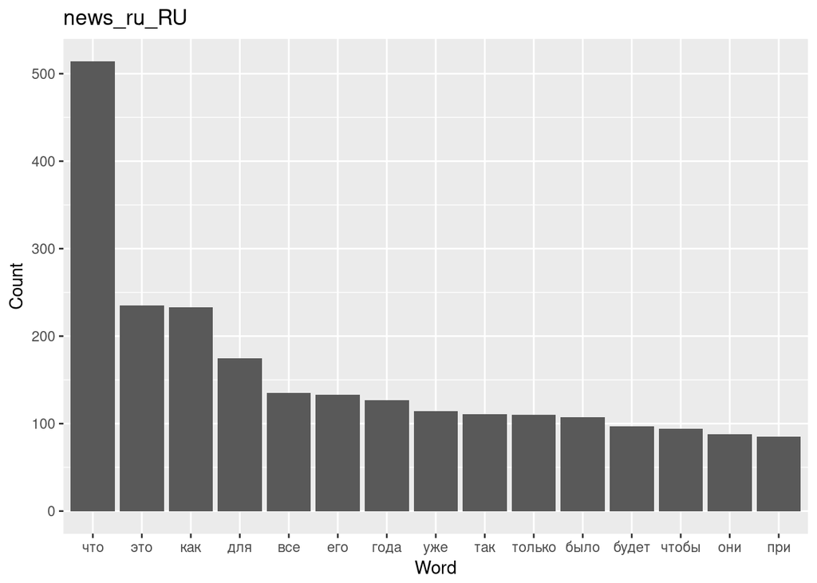

```r
for(idx in 1:nrow(subsamples)){
    f = freqDF(subsamples$Sample[[idx]], wordSize = c(5,20))
    hist <- ggplot(f, aes(x = reorder(word, -frequency), y = frequency)) +
            geom_bar(stat="identity") +
            labs(x = "Word", y = "Count", title = paste0(subsamples$Source[[idx]]))
    plot(hist)
}
```

Let’s look at that in German. Get the differences in most frequent words in German tweets, news, and blogs. Then get their respective counts:

```r
de_twitter_freq <- freqDF(subsamples$Sample[[1]], wordSize = c(5,20))
de_blogs_freq <- freqDF(subsamples$Sample[[2]], wordSize = c(5,20))
de_news_freq <- freqDF(subsamples$Sample[[3]], wordSize = c(5,20))
diff_twitter_words <- Reduce(setdiff, list(de_twitter_freq$word, de_blogs_freq$word, de_news_freq$word))
diff_blogs_words <- Reduce(setdiff, list(de_blogs_freq$word, de_twitter_freq$word, de_news_freq$word))
diff_news_words <- Reduce(setdiff, list(de_news_freq$word, de_twitter_freq$word, de_blogs_freq$word))
print(diff_twitter_words)
```

```
## [1] "jetzt"  "morgen" "meine"  "gerade" "danke"  "wäre"   "macht"
```

```r
print(diff_blogs_words)
```

```
## [1] "diese" "etwas" "alles"
```

```r
print(diff_news_words)
```

```
## [1] "prozent" "sagte"   "gegen"   "hatte"   "wurde"   "unter"
```

Pretty interesting to see that specific sources feature specific words more frequently. This leaves me with some action items for preprocessing and further exploration:

## Action items:

- Find out how to process word lengths in non-Latin languages (Russian, Finnish)
- Clean the data from stop words
- Explore the word frequency differnces based on source
- Based on the pre-processing above, collect metrics on n-grams
- Modeling the data can take into account the unique frequencies of specific words based on source context (e.g. “share” might occur more frequenctly in blogs and Twitter than in the news)